# Original Homework code

Frank Azorsa

9/16/2019

# Introduction to the Assigment # 2

This is the code for [Homework 02](https://fuzzyatelin.github.io/bioanth-stats/homework-02.html), on week three of AN597. This is homework associated with Modules [6](https://fuzzyatelin.github.io/bioanth-stats/module-06/module-06.html), [7](https://fuzzyatelin.github.io/bioanth-stats/module-07/module-07.html) and [8](https://fuzzyatelin.github.io/bioanth-stats/module-08/module-08.html).

#### The first question asks:

> Every Saturday morning, at the same time, a primatologist goes and sits in the forest to listen for titi monkey calls, counting the number of calls they hear in a 2 hour window from 5am to 7am. Based on previous knowledge, she believes that the mean number of calls she will hear in that time is exactly 15. Let X represent the appropriate Poisson random variable of the number of calls heard in each monitoring session.

### Question 1:

##### What is the probability that she will hear more than 8 calls during any given session?

```r
ppois (8, lambda = 15, lower.tail = FALSE)
```

```
## [1] 0.9625535
```

### Question 2:

##### What is the probability that she will hear no calls in a session?

```r
dpois(x=0, lambda = 15)
```

```
## [1] 3.059023e-07
```

### Question 3:

##### What is the probability that she will hear exactly 3 calls in a session?

```r
dpois(x=3, lambda =15)
```

```
## [1] 0.0001720701
```

### Question 4:

##### Plot the relevant Poisson mass function over the values in range 0 ≤ x ≤ 30.

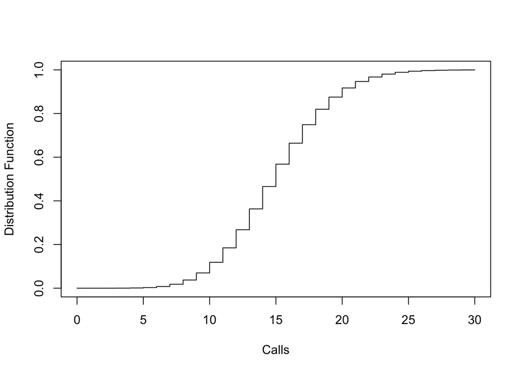

```r
rv <- 0:30
fs <- ppois (rv, lambda =15)
plot (rv, fs, type ="s", xlab = "Calls", ylab = "Distribution Function")
```

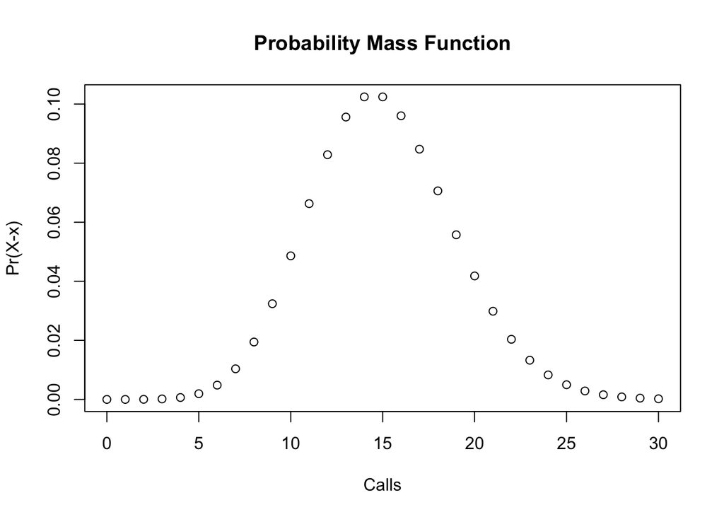

```r
ys <- 0:30
fs <- dpois (ys,lambda = 15)
plot(ys, fs, xlab = "Calls", ylab = "Pr(X-x)", main = "Probability Mass Function")
```

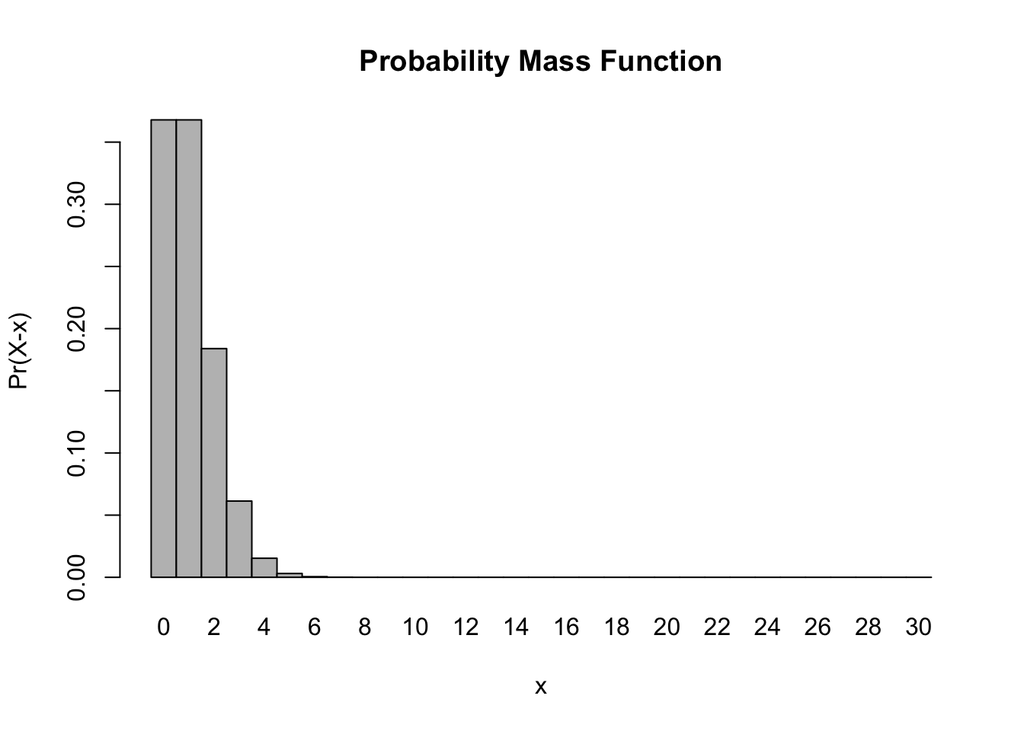

```r
x <- 0:30
l = 15
probset<- dpois (x=x,lambda = 1)
barplot(probset,names.arg=x,space = 0,xlab = "x", ylab="Pr(X-x)", main="Probability Mass Function")
```

### Question 5:

##### Simulate 104 results from this distribution (i.e., 2 years of Saturday monitoring sessions).

```r
sim <-rpois(104, lambda = 15)
sim
```

```
##   [1] 10 14 19 12 12 15 23 14 19 15 13  8 23 21 14 14  8 14 14 17 11 14 15
##  [24] 15 10 14 11 15 18 17  9 12 15 20 13 10 12 14 16 23  8 10 18 14 20 12
##  [47] 14 13 19 18  9 15 17 17 16 18 13 15 21 14 15 14 18 10 14 13 12 16 17
##  [70] 18 14 10 23  8 12 23 20 18 18 13 14 12 17 17 24 15 18 17 19 19 18 16
##  [93] 19 13 19 11 10 19 19 13 19 12  8  9
```

```r
summary(sim)
```

```
##    Min. 1st Qu.  Median    Mean 3rd Qu.    Max.
##    8.00   12.00   15.00   15.07   18.00   24.00
```

### Question 6:

##### Plot the simulated results using hist() and use xlim() to set the horizontal limits to be from 0 to 30. How does your histogram compare to the shape of the probability mass function you plotted above?

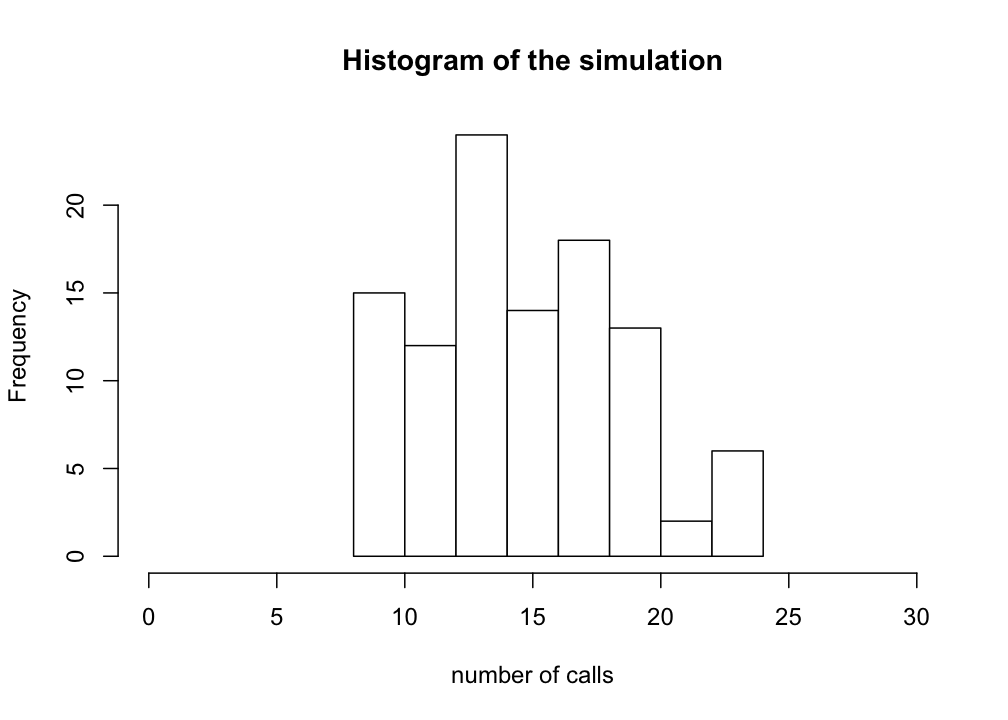

```r
hist(sim, xlim = c(0,30), main = "Histogram of the simulation", col = "white", xlab = "number of calls")
```

### Challenges:

> For the first three questions I used module 8, this [hangout](https://orfe.princeton.edu/~jqfan/fan/classes/245/rhandout2.pdf) which as very helpful to answer almost all questions, and this [website](https://rstudio-pubs-static.s3.amazonaws.com/456645_107fa2aa82de4b1da6c78c418bab9fe9.html) - so I spend some hours looking for examples that could help me to solve these questions.

> In the first three questions I am still confuse beetween ppois and dpois.

> I will really appreciate help with the annotations, I still have some problems with it.

> I still need to learn why I am using each code for each question, and also I am still working on the interpretation of the results.